# Wolbachia Infection Frequency

Notes on Reproducing Turelli Model Results

```r
library(tidyverse)
library(ggthemes)
library(scales)
library(latex2exp)

theme_set(theme_minimal(base_size=13))

update_geom_defaults("point", list(color = "midnightblue", alpha = 0.8))

source("R/infection_frequency.R")
```

## The Model

From (Turelli, Katznelson, and Ginsberg 2022), see also (Turelli and Barton 2022).

$$\begin{align}
p_{t+1} &= \frac{p_{t}F(1 - \mu)}{1 + p_{t}(F - 1 - s_{h}) + p_{t}^{2}s_{h}(1 - \mu F)}, \\
q_{ij} &= \left(\begin{array}{c} N \\ j \end{array}\right)(p^{\ast})^{j}(1 - p^{\ast})^{N - j}.
\end{align}$$

## Implementation

The first equation above is implemented as `infection_frequency_step` in the script `R/infection_frequency.R`.

```r
infection_frequency_step <- function(p_t,F_val,mu_val,sh_val){

  num_exp <- p_t*F_val*(1-mu_val)
  den_exp <- 1 + p_t*(F_val - 1 - sh_val) + (p_t^2)*sh_val*(1 - mu_val*F_val)

  p_t1 <- num_exp/den_exp

  return(max(0.0,min(p_t1,1.0)))

}
```

The function `turelli_iteration` in the script `R/infection_frequency.R` implements a time step with both equations above and where $F$ is a lognormal random variable.

```r
turelli_iteration <- function(p_val,F_val_m,F_val_CV,
                              sh_val,mu_val,N){

  F_val_r <- rnorm(1, mean=log(F_val_m), sd=sqrt(log(F_val_CV^2 + 1))) |>
    exp()
  p_star <- infection_frequency_step(p_val, F_val_r, mu_val, sh_val)

  return(rbinom(1, N, p_star) / N )

}
```

The function `turelli_simulation` in `R/infection_frequency.R` runs the simulation for a given set of parameters.

```r
turelli_simulation <- function(p_0,F_val_m,F_val_CV,
                               sh_val,mu_val,N,
                               max_iter=10^10, thresh = 10^(-8)){

  gen_i <- 0

  while (gen_i < max_iter & p_0 > thresh){
    p_0 <- turelli_iteration(p_0,F_val_m=F_val_m,F_val_CV=F_val_CV,
                             sh_val=sh_val,mu_val=mu_val,N=N)
    gen_i <- gen_i + 1
  }

  return(gen_i)

}
```

Figure 1 shows an example simulation based on `turelli_simulation`. For this simulation, we set $s_{h} = 0$ and $\mu = 0.02$. The initial frequency of infection is $p_{0} = 0.4$. The mean of the lognormal distribution for $F$ is $1.021$ and the coefficient of variation is $0.4$. The effective population size is $N = 1000$.

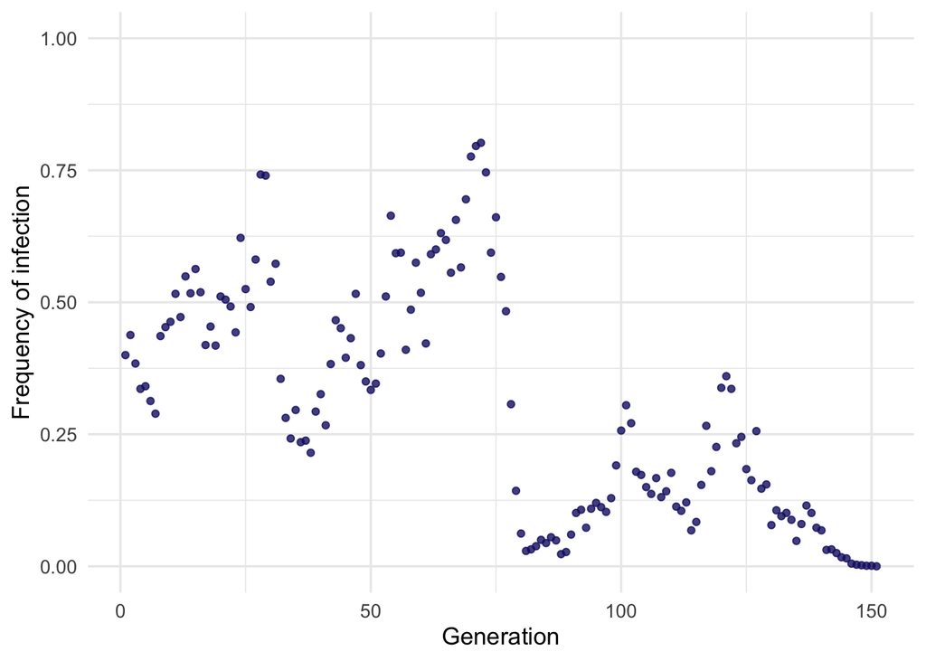

Figure 1: A single simulation of the Turelli model, here $s_{h} = 0$.

```r
p_0 <- 0.4
F_val_m <- 1.021
F_val_CV <- 0.4

mu_val <- 0.02
sh_val <- 0.0

N <- 1000

p <- turelli_simulation_p(p_0,F_val_m,F_val_CV,
                          sh_val,mu_val,N)

tibble(p=p) |>
  ggplot(aes(x=1:length(p),y=p)) +
  geom_point() +
  ylim(c(0,1)) +
  labs(x = "Generation", y = "Frequency of infection")
```

## Results

The script `turelli_et_al_2022_fig_02.R` contains code to reproduce Figure 2 from (Turelli, Katznelson, and Ginsberg 2022). That is, we run multiple simulations (25 per parameter setting) as in `turelli_simulation` for a range of $s_{h}$ values and for two choices of the mean of the lognormal distribution, so that $Median_{F} = 1.021$ and $Median_{F} = 1.05$. The results are saved in in the data files `model_results/fig_02_data_1.csv` and `model_results/fig_02_data_2.csv`.

```r
# Read in data
df_1 <- read_csv("model_results/fig_02_data_1.csv")
df_2 <- read_csv("model_results/fig_02_data_2.csv")
```

Figure 2 and Figure 3 show the distribution of persistence times for $Median_{F} = 1.021$ and $Median_{F} = 1.05$, respectively.

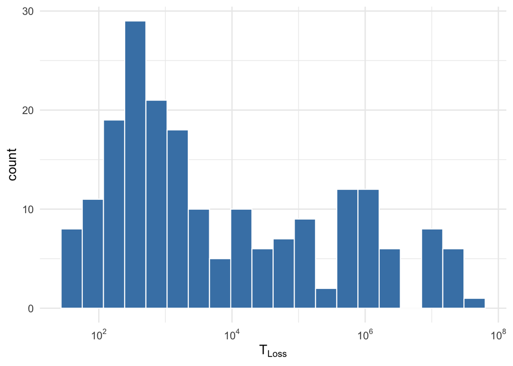

Figure 2: Distribution of persistence times for $Median_{F} = 1.021$.

```r
df_1 |>
  ggplot(aes(x=t_f)) +
  geom_histogram(bins=20,color="white",fill="steelblue") +
  scale_x_log10(breaks = trans_breaks("log10", function(x) 10^x),
                labels = trans_format("log10", math_format(10^.x))) +
  labs(x = TeX("$T_{Loss}$"))
```

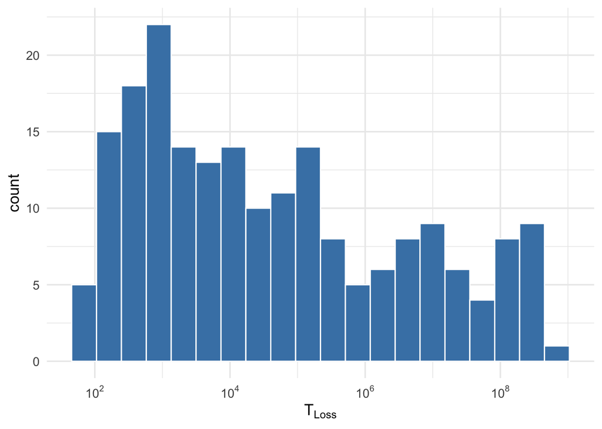

Figure 3: Distribution of persistence times for $Median_{F} = 1.05$.

```r
df_2 |>
  ggplot(aes(x=t_f)) +
  geom_histogram(bins=20,color="white",fill="steelblue") +
  scale_x_log10(breaks = trans_breaks("log10", function(x) 10^x),
                labels = trans_format("log10", math_format(10^.x))) +
  labs(x = TeX("$T_{Loss}$"))
```

Figure 4 reproduces Figure 2 from (Turelli, Katznelson, and Ginsberg 2022). The results are similar to those in the paper.

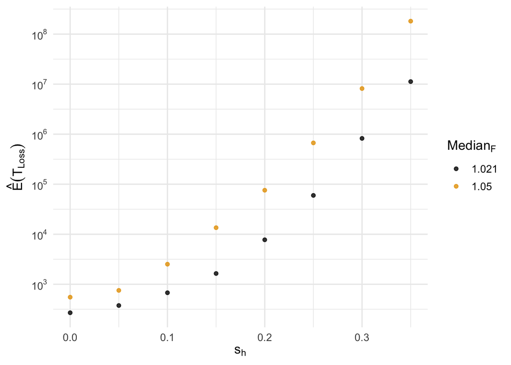

Figure 4: Reproducing the results from Figure 2 of (Turelli, Katznelson, and Ginsberg 2022).

```r
df_1_s <- df_1 |>
  group_by(sh_val) |>
  summarise(mean = mean(t_f), n = n()) |>
  mutate(F_val = "1.021")

df_2_s <- df_2 |>
  group_by(sh_val) |>
  summarise(mean = mean(t_f), n = n())  |>
  mutate(F_val = "1.05")

df_12 <- rbind(df_1_s,df_2_s)

df_12 %>%
  ggplot(aes(x=sh_val, y = mean,color=F_val)) +
  geom_point() +
  scale_y_log10(breaks = trans_breaks("log10", function(x) 10^x),
                labels = trans_format("log10", math_format(10^.x))) +
  scale_color_colorblind() +
  labs(x = TeX("$s_{h}$"), y = TeX("$\\hat{E}(T_{Loss})$"), color=TeX("$Median_{F}$"))
```

## References

Turelli, Michael, and Nicholas H Barton. 2022. “Why Did the Wolbachia Transinfection Cross the Road? Drift, Deterministic Dynamics, and Disease Control.” *Evolution Letters* 6 (1): 92–105.

Turelli, Michael, Andrew Katznelson, and Paul S Ginsberg. 2022. “Why Wolbachia-Induced Cytoplasmic Incompatibility Is so Common.” *Proceedings of the National Academy of Sciences* 119 (47): e2211637119.